# OBV2 Notebook: Plea bargaining

## About the notebook

This is the HTML output of an R Notebook. By default it shows the chunks of R code that generate the document. Click the ‘hide’ button above individual chunks of code, or the ‘Code’ button at the very top of the page, if you want to make them go away. The underlying RMarkdown file can be downloaded here.

## Questions

Comparison of defendants who are found guilty (ie, defendant pleads not guilty and is convicted by jury) and those who plead guilty.

Plea bargaining and types of trial; changes over time

Severity of sentencing for defendants who plead not guilty

Gender and plea bargaining

## About the data

Summary data about single-defendant Old Bailey Online trials 1780-1880 in sessions that have been tagged in the Old Bailey Corpus (v2). This includes OBO trial reference and session date; whether a trial report contains tagged speech; whether the defendant speaks in the trial; total word count; spoken word count (OBC); count of OBC-tagged utterances; spoken word and utterance counts for the defendant; counts of types of utterance for defendants; offence, verdict and sentence categories; defendant name, gender, age (if present) and occupation (as tagged, if present).

- Trials with multiple defendants have been excluded from the dataset because of the added complexity of matching them to utterances (and they aren’t always individually named).
- A few OBC sessions have been excluded from the dataset because of tagging issues.

Further calculated columns have been added within R.

## Notes on data structures/naming

- obc_type = obc tagging type
  - tagged
  - untagged
- speech type
  - no_speech (equivalent to obc_type untagged)
  - deft_speaks
  - deft_silent
- trial length (total words)
  - <= 50 words = ‘short’
  - 51-250 words = ‘medium’
  - more than 250 words = ‘long’
- trial length (tagged speech)
  - uses same lengths as total words, but hmmm…
- offcat = obo offence category
- offsub = obo offence subcategory
- vercat = obo verdict category
  - g = guilty
  - ng = not guilty
  - gng = guilty+not guilty (ie, excludes misc, special etc - very small numbers)
- guilty types
  - notGuilty = tried and acquitted
  - foundGuilty = pleaded not guilty, tried and convicted
  - pleadedGuilty = pleaded guilty
- versub = obo verdict subcategory
- puncat = obo sentence category
- punsub = obo sentence subcategory
- age group
  - 18 and under
  - 19 to 25
  - 26 to 35
  - 36 and over

## R preliminaries

```r
# necessary packages
library(plyr)
library(dplyr)
library(tidyr)
library(ggplot2)
library(scales)
```

```r
# reusable customisations and functions
set_graphs_theme_ltop <- theme(legend.position = "top", axis.text=element_text(size=6), title=element_text(size=8), legend.title=element_text(size=8), legend.text=element_text(size=6), plot.title=element_text(size=16))
set_graphs_theme_g <- theme(axis.text=element_text(size=6), title=element_text(size=8), legend.title=element_text(size=8), legend.text=element_text(size=6), plot.title=element_text(size=16))
# Multiple plot function
#
# ggplot objects can be passed in ..., or to plotlist (as a list of ggplot objects)
# - cols:   Number of columns in layout
# - layout: A matrix specifying the layout. If present, 'cols' is ignored.
#
# If the layout is something like matrix(c(1,2,3,3), nrow=2, byrow=TRUE),
# then plot 1 will go in the upper left, 2 will go in the upper right, and
# 3 will go all the way across the bottom.
#
multiplot <- function(..., plotlist=NULL, file, cols=1, layout=NULL) {
  library(grid)

  # Make a list from the ... arguments and plotlist
  plots <- c(list(...), plotlist)

  numPlots = length(plots)

  # If layout is NULL, then use 'cols' to determine layout
  if (is.null(layout)) {
    # Make the panel
    # ncol: Number of columns of plots
    # nrow: Number of rows needed, calculated from # of cols
    layout <- matrix(seq(1, cols * ceiling(numPlots/cols)),
                     ncol = cols, nrow = ceiling(numPlots/cols))
  }

  if (numPlots==1) {
    print(plots[[1]])

  } else {
    # Set up the page
    grid.newpage()
    pushViewport(viewport(layout = grid.layout(nrow(layout), ncol(layout))))

    # Make each plot, in the correct location
    for (i in 1:numPlots) {
      # Get the i,j matrix positions of the regions that contain this subplot
      matchidx <- as.data.frame(which(layout == i, arr.ind = TRUE))

      print(plots[[i]], vp = viewport(layout.pos.row = matchidx$row,
                                      layout.pos.col = matchidx$col))
    }
  }
}
```

## Get the data

full dataset in TSV file

```r
# read in the full data
obv2_defendants_trials <- read.table("obv_defendants_trials.tsv",
                   header=TRUE,
                   sep="\t")
```

```r
## filter out stuff you won't want (f) and add new columns you will
### filter: guilty/not guilty verdicts only; exclude 1784 (single trial) and 1780
obv2_f_gng <- obv2_defendants_trials %>% filter(grepl('uilty',deft_vercat), year != 1784, year !=1780)
## add obc_type column for tagged/untagged trials (*requires plyr)
obv2_f_gng$obc_type <- revalue(obv2_f_gng$speech, c("deft_speaks"="tagged", "deft_silent"="tagged", "no_speech"="untagged"))
## add trial length column (total words) - <=50 'short'; 51-250 'medium'; 251+ 'long'
obv2_f_gng$trial_length_lms <- ifelse(obv2_f_gng$trial_total_wc > 250, "long", ifelse(obv2_f_gng$trial_total_wc > 50, "medium", "short"))
## speech word count, tagged trials only
## need to force speech_wc to numeric
## will generate NA warnings, don't worry about them
obv2_f_gng$trial_speech_length_lms <-  ifelse(as.numeric(as.character(obv2_f_gng$trial_speech_wc)) > 250, "long", ifelse( as.numeric(as.character(obv2_f_gng$trial_speech_wc)) > 50, "medium", "short"))
```

```
NAs introduced by coercionNAs introduced by coercion
```

```r
## create new column for verdict type pleaded guilty | found guilty | not guilty
obv2_f_gng$verdict_type <- ifelse(grepl('pleaded', obv2_f_gng$deft_versub), "pleadedGuilty",  ifelse(obv2_f_gng$deft_vercat =='guilty', 'foundGuilty', 'notGuilty')  )
## add decade column - this would be a lot simpler if you'd started with year 0...
## a dreadful hacky thing, must be a more mathematically literate way :-D
## may not be best periodization anyway... let's see how it goes
obv2_f_gng$decade <- paste( (as.numeric(substr(obv2_f_gng$year-1, 1, 3)) *10) +1, (as.numeric(substr(obv2_f_gng$year-1, 1, 3)) *10) +10, sep='-')
## add age group column
## first try at this: may generate warnings but numbers look ok
obv2_f_gng$age_group <- ifelse(obv2_f_gng$deft_age == 'NULL', 'no age',
  ifelse(as.numeric(as.character(obv2_f_gng$deft_age)) <= 18, '18&under',
    ifelse(as.numeric(as.character(obv2_f_gng$deft_age)) >= 19 & as.numeric(as.character(obv2_f_gng$deft_age)) <= 25, '19-25',
      ifelse(as.numeric(as.character(obv2_f_gng$deft_age)) >= 26 & as.numeric(as.character(obv2_f_gng$deft_age)) <= 35, '26-35',
             '36&over') ) ) )
```

```
NAs introduced by coercionNAs introduced by coercionNAs introduced by coercionNAs introduced by coercionNAs introduced by coercion
```

```r
## filter out not guilty
obv2_f_gng_exng <- obv2_f_gng %>% filter(verdict_type != 'notGuilty')
## 1831-1880 for pleaded/found guilty analysis
obv2_f_gng_1831 <- obv2_f_gng %>% filter(year > 1830)
## 1831-1880 also filtering out not guilty
obv2_f_gng_exng_1831 <- obv2_f_gng_exng %>% filter(year > 1830)
## 1810-20 to check the increase in guilty pleas
## add this to the plot code ...
#obv2_f_gng_exng_1810 <- obv2_f_gng_exng %>% filter(year > 1810, year <= 1820)
```

```r
# summarise all the things!
## except the ones you do later
### breakdown by verdict type *excl* ng, year
obv2_gng_exng_year <- obv2_f_gng_exng %>% select(year, verdict_type) %>% group_by(year, verdict_type) %>% summarise(n_v_type = n())
### breakdwon by verdict type *incl* ng, year
obv2_gng_year <- obv2_f_gng  %>% select(year, verdict_type) %>% group_by(year, verdict_type) %>% summarise(n_v_type = n())
### breakdown by vercat, year
obv2_gng_year_vercat <- obv2_f_gng %>% select(year, deft_vercat) %>% group_by(year, deft_vercat) %>% summarise(n_vercat = n())
### breakdown by verdict type and puncat (guilty only)
obv2_gng_vtype_puncat <- obv2_f_gng_exng %>% select(verdict_type, deft_puncat) %>% group_by(verdict_type, deft_puncat) %>% summarise(nvp = n())
## break down by tagged type and offcat
obv2_f_obc_type_offcat <-   obv2_f_gng %>% select(obc_type, deft_offcat) %>% group_by(obc_type, deft_offcat) %>% summarise(ntrials = n())
```

```r
## re-order from default so found/pleaded together when not guilty is included in comparison
obv2_f_gng$v_type2 <- factor(obv2_f_gng$verdict_type, levels = c('notGuilty', 'foundGuilty', 'pleadedGuilty'))

## reverse
obv2_f_gng$v_type3 <- factor(obv2_f_gng$verdict_type, levels = c('pleadedGuilty', 'foundGuilty', 'notGuilty'))
```

## Revisit guilty/not guilty verdicts

### Stacked bar chart

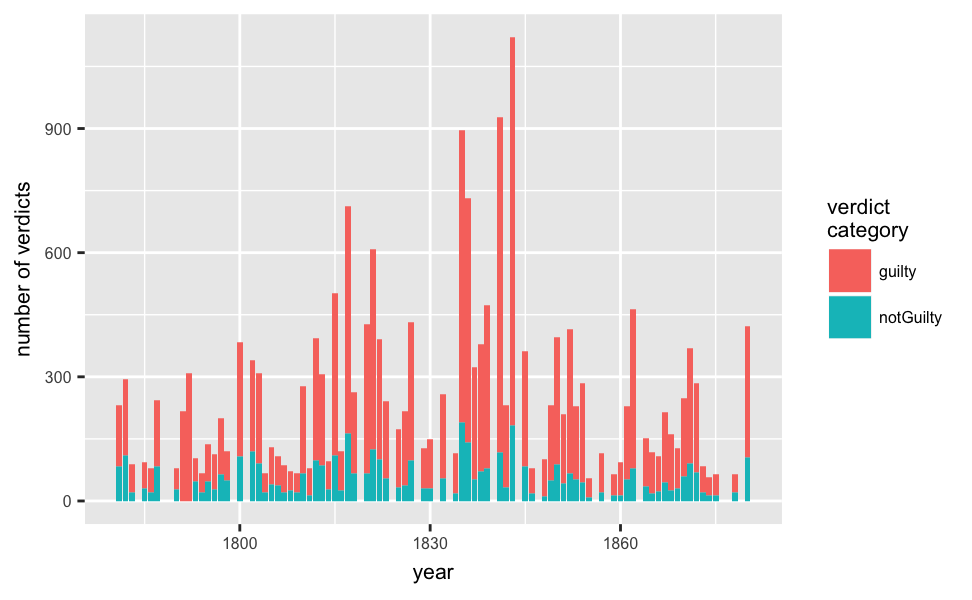

```r
ggplot(data=obv2_gng_year_vercat, aes(x=year,y=n_vercat)) +
  geom_bar(position="stack",stat='identity', aes(fill=deft_vercat)) +
  set_graphs_theme_g +
  labs(y="number of verdicts", fill="verdict\ncategory")
```

### Stacked proportional chart

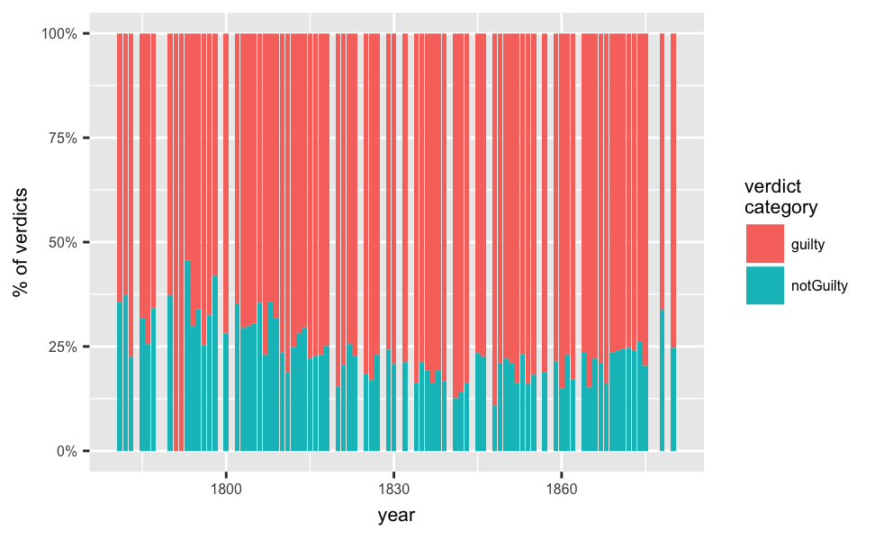

```r
ggplot(obv2_gng_year_vercat,aes(x = year, y = n_vercat, fill=deft_vercat)) +
  geom_bar(position= "fill", stat='identity') +
  scale_y_continuous(labels = percent_format()) +
  set_graphs_theme_g + labs(y="% of verdicts", fill="verdict\ncategory")
```

## Comparisons of found/pleaded guilty

### Proportional stacked bar (including not guilty)

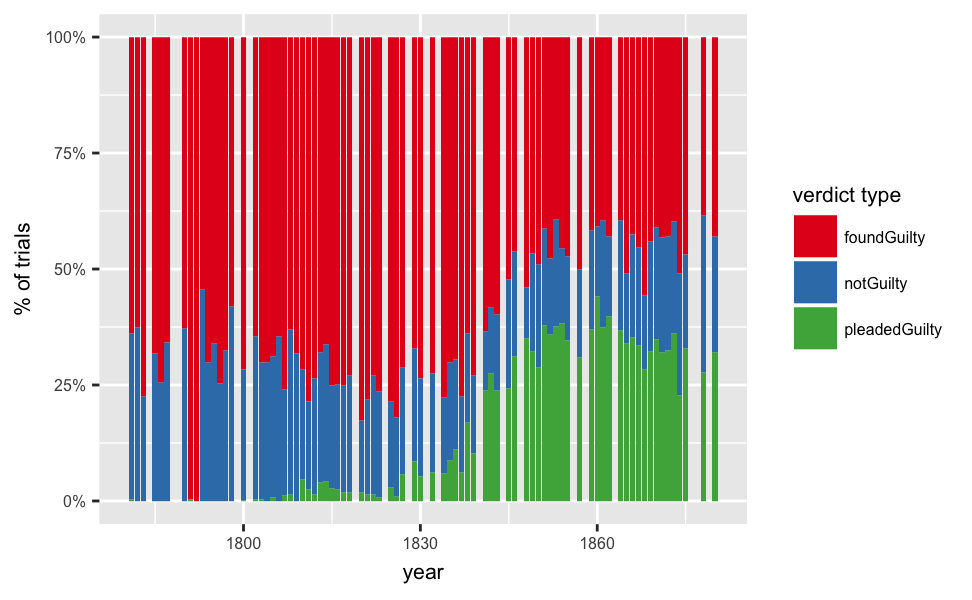

```r
ggplot(data=obv2_gng_year, aes(x=year, y=n_v_type)) +
  geom_bar(position="fill",stat='identity', aes(fill=verdict_type)) +
  set_graphs_theme_g + labs(y="% of trials", fill="verdict type") +
  scale_y_continuous(labels = percent_format()) +
  scale_fill_brewer(palette = "Set1")
```

### Stacked bar, guilty only

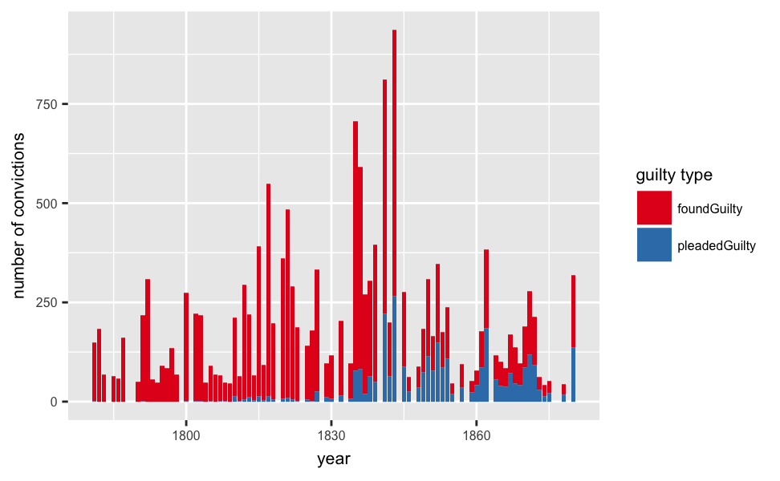

```r
ggplot(data=obv2_gng_exng_year, aes(x=year, y=n_v_type)) +
  geom_bar(position="stack",stat='identity', aes(fill=verdict_type)) +
  set_graphs_theme_g + labs(y="number of convictions", fill="guilty type") +
  scale_fill_brewer(palette = "Set1")
```

### proportional stacked bar, guilty only

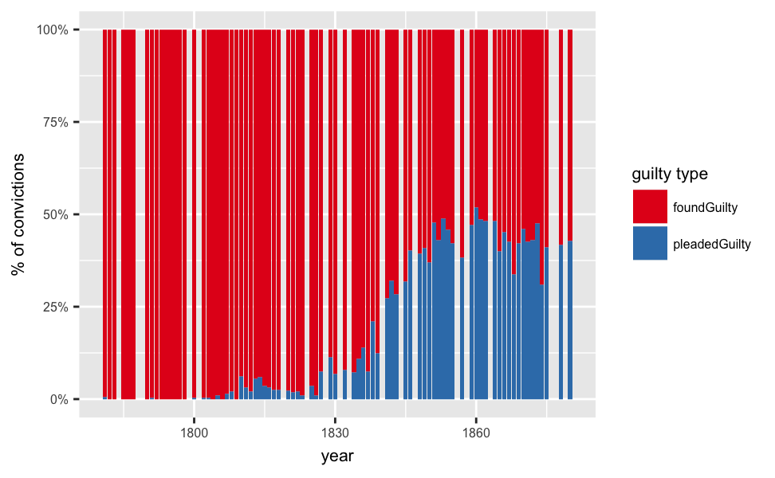

```r
ggplot(data=obv2_gng_exng_year, aes(x=year, y=n_v_type)) +
  geom_bar(position="fill",stat='identity', aes(fill=verdict_type)) +
  set_graphs_theme_g + labs(y="% of convictions", fill="guilty type") +
  scale_y_continuous(labels = percent_format())  +
  scale_fill_brewer(palette = "Set1")
```

## Found guilty v pleaded guilty, 1831-1880

Excluding 1781-1830 because there are so few guilty pleas

### Offence categories and found/pleaded guilty

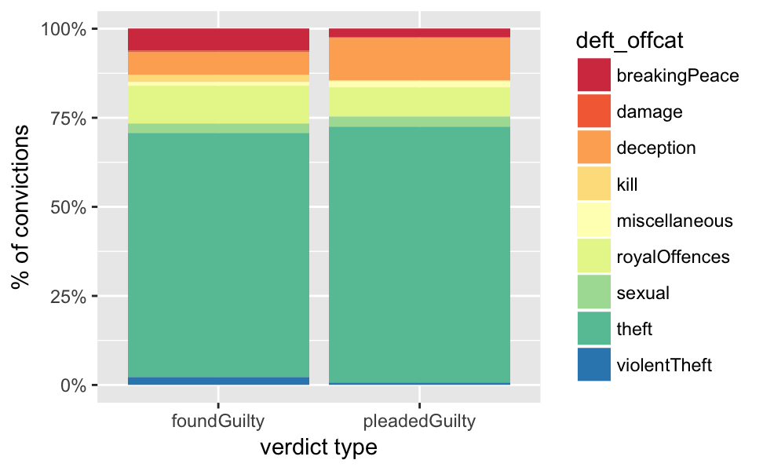

```r
ggplot(obv2_f_gng_exng_1831, aes(verdict_type) ) +
  geom_bar(position='fill', aes(fill=deft_offcat)) +
  scale_y_continuous(labels = percent_format()) +
  labs(y="% of convictions", x="verdict type") +
  scale_fill_brewer(palette = "Spectral")
```

### Found/pleaded guilty ratio for each offence category

Overall, just under 31% of convictions 1831-1880 were the result of the defendant pleading guilty, indicated by the dotted guide line (as is often the case, theft is so dominant that it strongly influences the average).

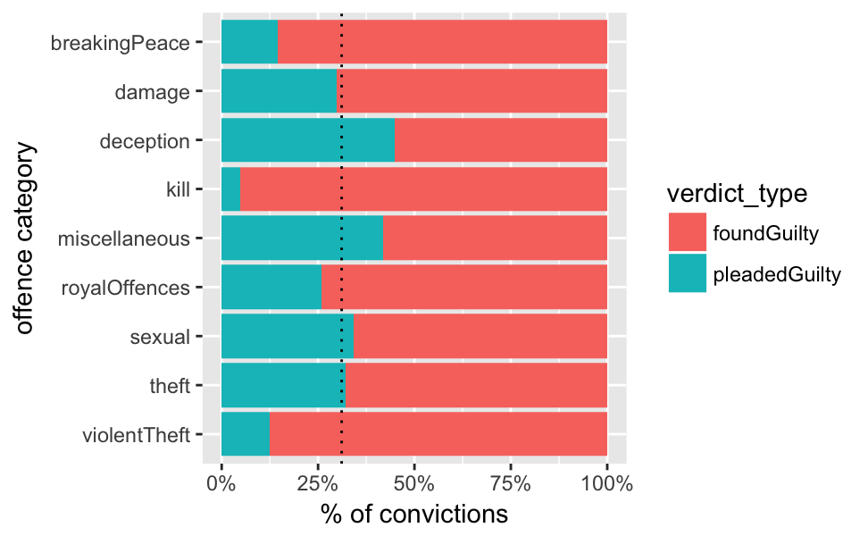

```r
ggplot(obv2_f_gng_exng_1831, aes(deft_offcat) ) +
  geom_bar(position='fill', aes(fill=verdict_type)) +
  geom_hline(aes(yintercept = r_pleaded), obv2_f_gng_exng_1831_calc, linetype="dotted" ) +
  coord_flip() +
  xlim("violentTheft", "theft", "sexual", "royalOffences","miscellaneous", "kill", "deception", "damage", "breakingPeace") +
  scale_y_continuous(labels = percent_format()) +
  labs(y="% of convictions", x="offence category")
```

### Sentence categories and found/pleaded guilty

- the blank category indicates that no sentence is recorded in the Proceedings (noPunish is not the same: it refers to outcomes such as sentence respited or pardon).
- miscPunish primarily consists of fines and recognizances

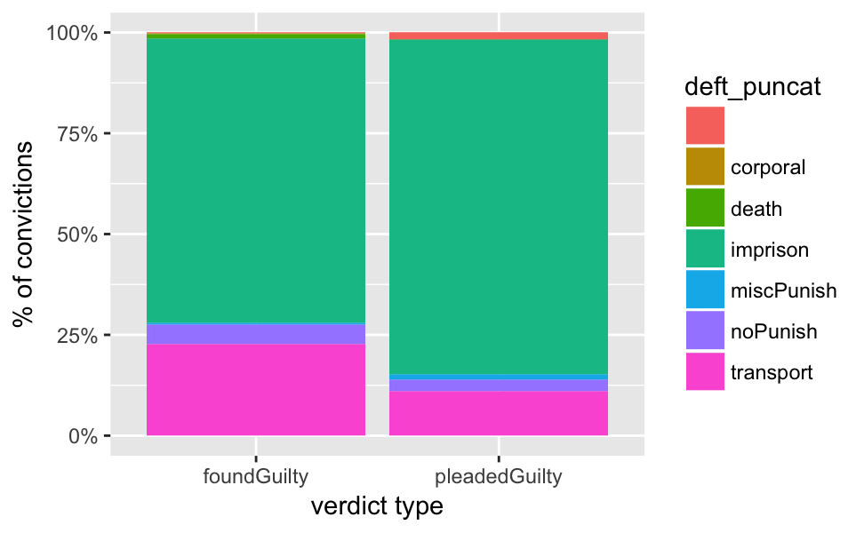

```r
ggplot(obv2_f_gng_exng_1831, aes(verdict_type) ) +
  geom_bar(position='fill', aes(fill=deft_puncat)) +
  #geom_bar(aes(x="")) +
  scale_y_continuous(labels = percent_format()) +
  labs(y="% of convictions", x="verdict type")
```

### Found/pleaded guilty ratio for each sentence category

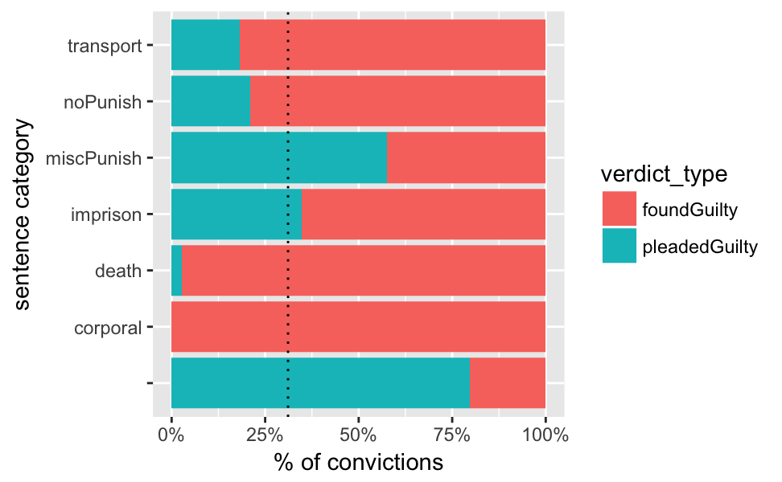

```r
# calculate overall ratio of found/pleaded to create average guide line
obv2_f_gng_exng_1831_calc <- obv2_f_gng_exng_1831 %>% select(verdict_type) %>% group_by(verdict_type) %>% summarise(vtype = n()) %>% spread(verdict_type, vtype) %>% mutate(total_v = foundGuilty + pleadedGuilty, r_found = foundGuilty / (foundGuilty + pleadedGuilty), r_pleaded = pleadedGuilty / (foundGuilty + pleadedGuilty) )
ggplot(obv2_f_gng_exng_1831, aes(deft_puncat) ) +
  geom_bar(position='fill', aes(fill=verdict_type)) +
  geom_hline(aes(yintercept = r_pleaded), obv2_f_gng_exng_1831_calc, linetype="dotted" ) +
  coord_flip() +
  scale_y_continuous(labels = percent_format()) +
  labs(y="% of convictions", x="sentence category")
```

### Verdict type and defendant gender

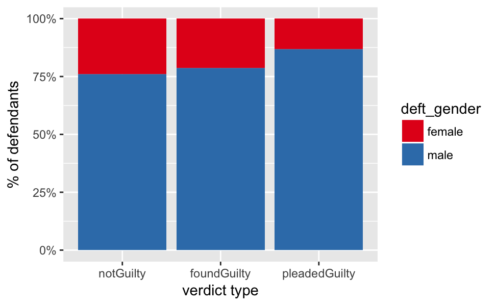

```r
ggplot(obv2_f_gng %>% filter(deft_gender !=""), aes(v_type2) ) +
  geom_bar(position='fill', aes(fill=deft_gender)) +
  scale_y_continuous(labels = percent_format()) +
  labs(y="% of defendants", x="verdict type") +
  scale_fill_brewer(palette = "Set1")
```

### Verdict type and defendant gender, by decade

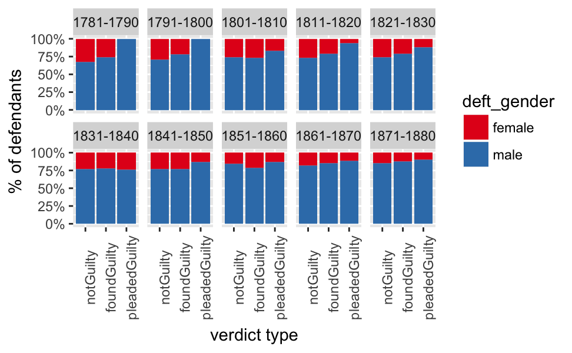

```r
ggplot(obv2_f_gng %>% filter(deft_gender !=""), aes(v_type2) ) +
  geom_bar(position='fill', aes(fill=deft_gender)) +
  facet_wrap(~decade, ncol=5) +
  scale_y_continuous(labels = percent_format()) +
  labs(y="% of defendants", x="verdict type") +
  theme(axis.text.x=element_text(angle=90))  +
  scale_fill_brewer(palette = "Set1")
```

## Verdict types and words

### Verdict type and tagged speech type, overall 1781-1880

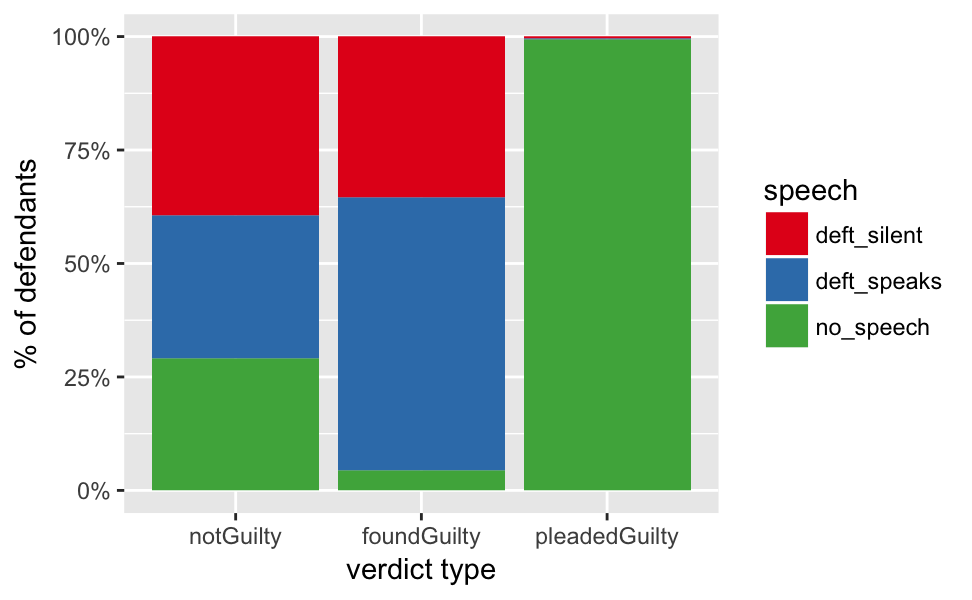

```r
ggplot(obv2_f_gng, aes(v_type2) ) +
  geom_bar(position='fill', aes(fill=speech)) +
  scale_y_continuous(labels = percent_format()) +
  labs(y="% of defendants", x="verdict type") +
  scale_fill_brewer(palette = "Set1")
```

### Verdict type and speech tagged type, by decade

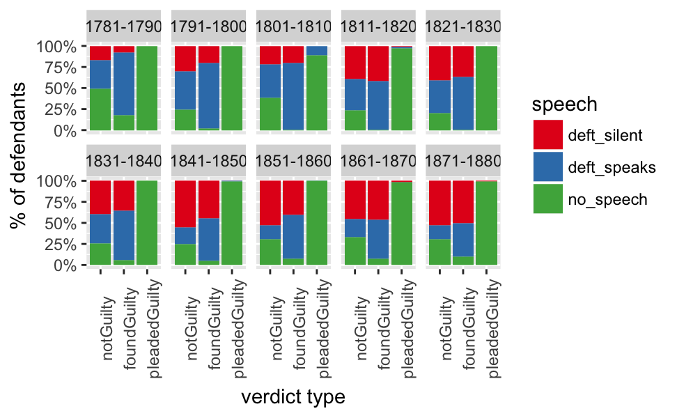

```r
ggplot(obv2_f_gng, aes(v_type2) ) +
  geom_bar(position='fill', aes(fill=speech)) +
  facet_wrap(~decade, ncol=5) +
  scale_y_continuous(labels = percent_format()) +
  labs(y="% of defendants", x="verdict type")  +
  theme(axis.text.x=element_text(angle=90)) +
  scale_fill_brewer(palette = "Set1")
```

### Verdict type and total trial length, by decade

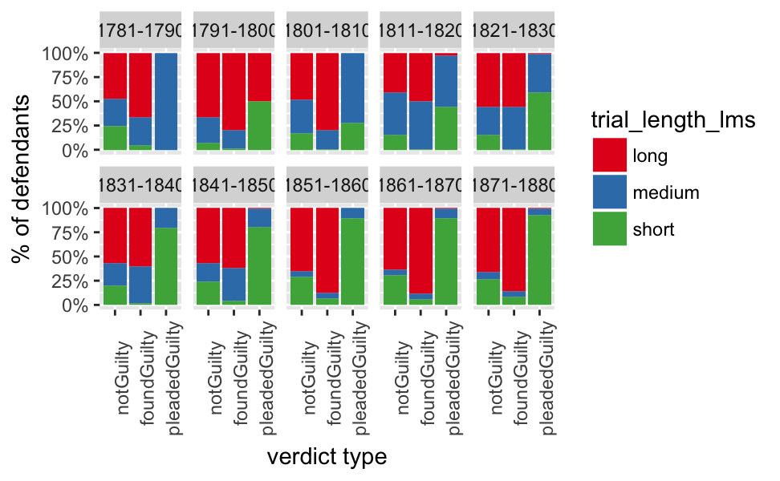

```r
ggplot(obv2_f_gng, aes(v_type2) ) +
  geom_bar(position='fill', aes(fill=trial_length_lms)) +
  facet_wrap(~decade, ncol=5) +
  scale_y_continuous(labels = percent_format()) +
  labs(y="% of defendants", x="verdict type")  +
  theme(axis.text.x=element_text(angle=90)) +
  scale_fill_brewer(palette = "Set1")
```

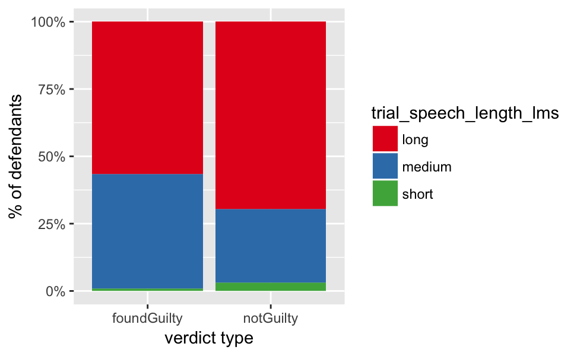

```r
ggplot(obv2_f_gng %>% filter(speech !="no_speech", verdict_type !="pleadedGuilty"), aes(verdict_type) ) +
  geom_bar(position='fill', aes(fill=trial_speech_length_lms)) +
  scale_y_continuous(labels = percent_format()) +
  labs(y="% of defendants", x="verdict type")  +
  scale_fill_brewer(palette = "Set1")
```

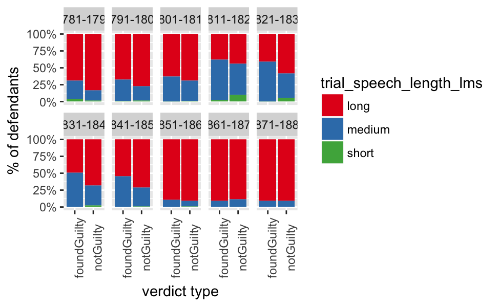

```r
ggplot(obv2_f_gng %>% filter(speech !="no_speech", verdict_type !="pleadedGuilty"), aes(verdict_type) ) +
  geom_bar(position='fill', aes(fill=trial_speech_length_lms)) +
  facet_wrap(~decade, ncol=5) +
  scale_y_continuous(labels = percent_format()) +
  labs(y="% of defendants", x="verdict type")  +
  theme(axis.text.x=element_text(angle=90)) +
  scale_fill_brewer(palette = "Set1")
```

## Total word counts and verdict types

### Including not guilty

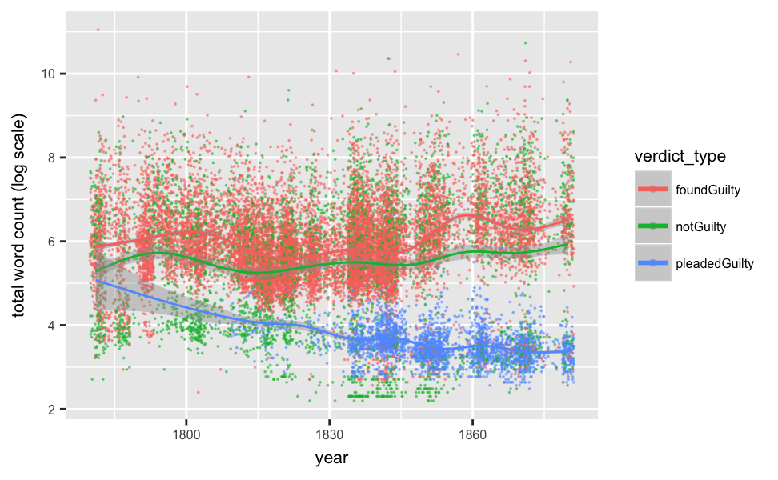

```r
ggplot(data=obv2_f_gng, mapping = aes(x=year, y=log(trial_total_wc), color=verdict_type)) +
    geom_jitter(size=0.01, width=1.2, alpha=1/2) +
  geom_smooth(size=0.5) +
  labs(y="total word count (log scale)") +
   set_graphs_theme_g +
  guides(color = guide_legend(override.aes = list(size=1)))
```

### Guilty only 1831-1880

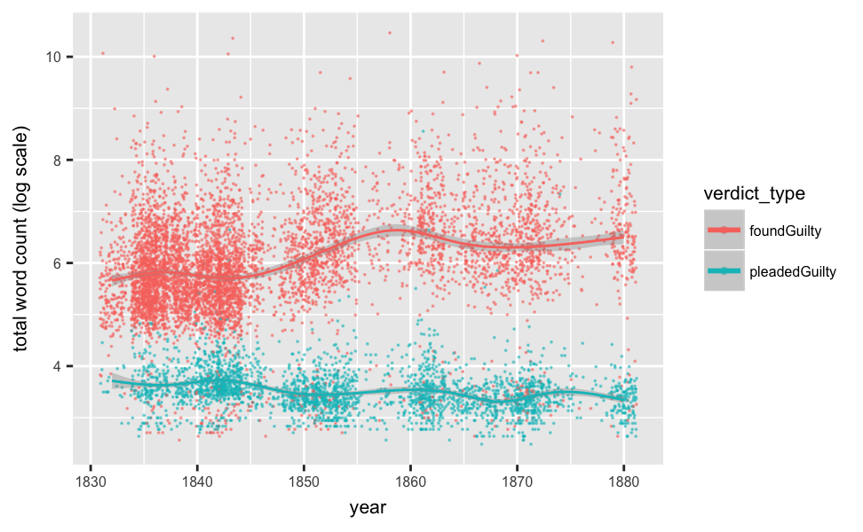

```r
ggplot(data=obv2_f_gng %>% filter(verdict_type !="notGuilty", year > 1830), mapping = aes(x=year, y=log(trial_total_wc), color=verdict_type)) +
    geom_jitter(size=0.01, width=1.2, alpha=1/2) +
  geom_smooth(size=0.5) +
  labs(y="total word count (log scale)") +
   set_graphs_theme_g +
  guides(color = guide_legend(override.aes = list(size=1)))
```

### Compare found guilty and not guilty 1831-1880

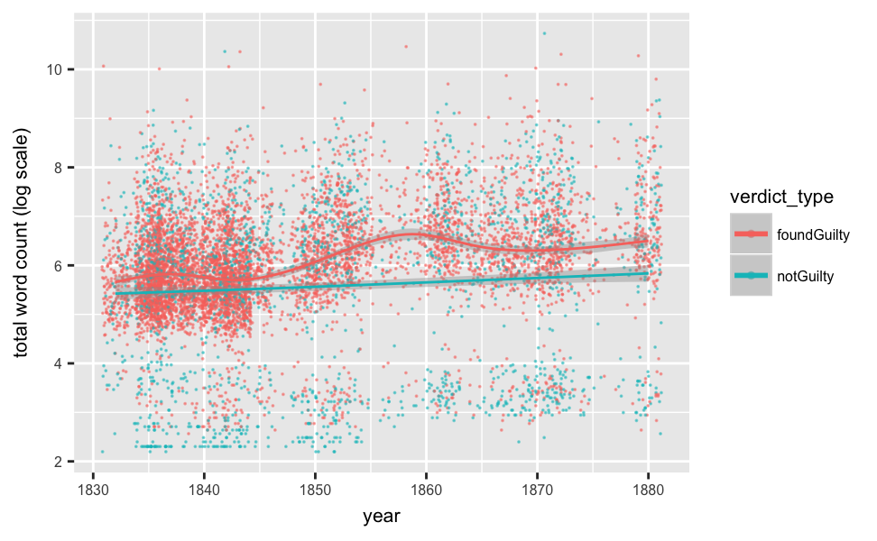

```r
ggplot(data=obv2_f_gng %>% filter(verdict_type !="pleadedGuilty", year > 1830), mapping = aes(x=year, y=log(trial_total_wc), color=verdict_type)) +
    geom_jitter(size=0.01, width=1.2, alpha=1/2) +
  geom_smooth(size=0.5) +
  labs(y="total word count (log scale)") +
   set_graphs_theme_g +
  guides(color = guide_legend(override.aes = list(size=1)))
```

## Tagged speech word counts

Only 20 trials with pleadedGuilty verdict type contain tagged speech.

### Compare found guilty and not guilty

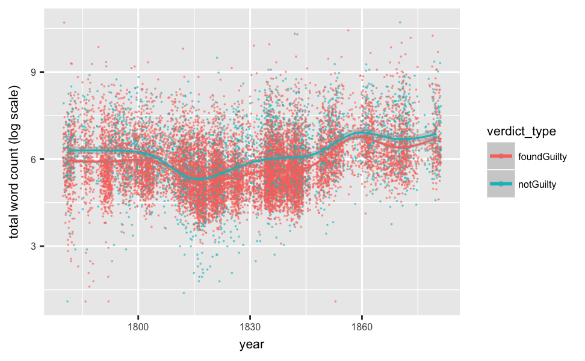

```r
ggplot(data=obv2_f_gng %>% filter(speech !="no_speech", verdict_type !="pleadedGuilty"), mapping = aes(x=year, y=log(as.numeric(as.character(trial_speech_wc)) ), color=verdict_type)) +
    geom_jitter(size=0.01, width=1.2, alpha=1/2) +
  geom_smooth(size=0.5) +
  labs(y="total word count (log scale)") +
   set_graphs_theme_g +
  guides(color = guide_legend(override.aes = list(size=1)))
```

### Defendant speech words count: compare found guilty and not guilty

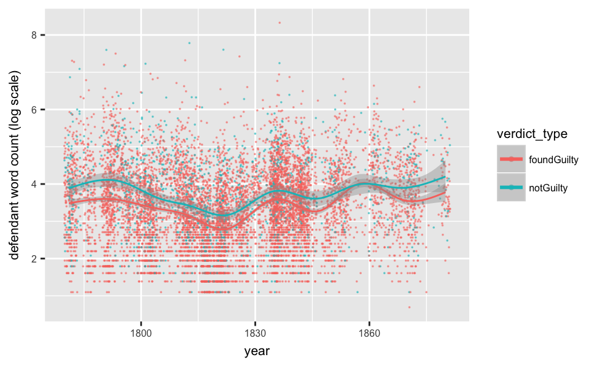

```r
ggplot(data=obv2_f_gng %>% filter(speech =="deft_speaks", verdict_type !="pleadedGuilty"), mapping = aes(x=year, y=log(as.numeric(as.character(deft_total_wc)) ), color=verdict_type)) +
    geom_jitter(size=0.01, width=1.2, alpha=1/2) +
  geom_smooth(size=0.5) +
  labs(y="defendant word count (log scale)") +
   set_graphs_theme_g +
  guides(color = guide_legend(override.aes = list(size=1)))
```